# EDA

```python
import pandas as pd
import numpy as np

import matplotlib.pyplot as plt

import warnings
warnings.filterwarnings(action='ignore')
```

https://data.cityofchicago.org/Transportation/2019_Nov1_14/s7xg-7axx

## Load Data and Take a Look

From Data, there are 4505930 trips between Nov. 1 2019 to Nov. 14 2019 (two weeks)

```python
trip = pd.read_csv('data/trip.csv')
```

```python
print('shape of dataset:', trip.shape)
trip.head(3)
```

```
shape of dataset: (4505930, 18)
```

|  | Trip Start Timestamp | Trip End Timestamp | Trip Seconds | Trip Miles | Pickup Census Tract | Dropoff Census Tract | Pickup Community Area | Dropoff Community Area | Fare | Tip | Additional Charges | Trip Total | Shared Trip Authorized | Trips Pooled | Pickup Centroid Latitude | Pickup Centroid Longitude | Dropoff Centroid Latitude | Dropoff Centroid Longitude |
| --- | --- | --- | --- | --- | --- | --- | --- | --- | --- | --- | --- | --- | --- | --- | --- | --- | --- | --- |
| 0 | 11/01/2019 12:00:00 AM | 11/01/2019 12:00:00 AM | 165.0 | 0.6 | 1.703132e+10 | 1.703132e+10 | 32.0 | 32.0 | 2.5 | 0.0 | 2.55 | 5.05 | False | 1 | 41.870607 | -87.622173 | 41.877406 | -87.621972 |
| 1 | 11/01/2019 12:00:00 AM | 11/01/2019 12:15:00 AM | 823.0 | 5.4 | 1.703103e+10 | 1.703108e+10 | 3.0 | 8.0 | 10.0 | 0.0 | 2.55 | 12.55 | False | 1 | 41.958155 | -87.653022 | 41.893216 | -87.637844 |
| 2 | 11/01/2019 12:00:00 AM | 11/01/2019 12:15:00 AM | 683.0 | 5.6 | 1.703110e+10 | 1.703116e+10 | 10.0 | 16.0 | 10.0 | 3.0 | 2.55 | 15.55 | False | 1 | 41.972132 | -87.797635 | 41.950212 | -87.712814 |

```python
trip.info()
```

```
<class 'pandas.core.frame.DataFrame'>
RangeIndex: 4505930 entries, 0 to 4505929
Data columns (total 18 columns):
 #   Column                      Dtype
---  ------                      -----
 0   Trip Start Timestamp        object
 1   Trip End Timestamp          object
 2   Trip Seconds                float64
 3   Trip Miles                  float64
 4   Pickup Census Tract         float64
 5   Dropoff Census Tract        float64
 6   Pickup Community Area       float64
 7   Dropoff Community Area      float64
 8   Fare                        float64
 9   Tip                         float64
 10  Additional Charges          float64
 11  Trip Total                  float64
 12  Shared Trip Authorized      bool
 13  Trips Pooled                int64
 14  Pickup Centroid Latitude    float64
 15  Pickup Centroid Longitude   float64
 16  Dropoff Centroid Latitude   float64
 17  Dropoff Centroid Longitude  float64
dtypes: bool(1), float64(14), int64(1), object(2)
memory usage: 588.7+ MB
```

### Columns in this Dataset and their description:

| Column Name | Description | Type |
| --- | --- | --- |
| Trip Start Timestamp | When the trip started, rounded to the nearest 15 minutes. | Date & Time |
| Trip End Timestamp | When the trip ended, rounded to the nearest 15 minutes. | Date & Time |
| Trip Seconds | Time of the trip in seconds. | Number |
| Trip Miles | Distance of the trip in miles. | Number |
| Pickup Census Tract | The Census Tract where the trip began. This column often will be blank for locations outside Chicago. | Plain Text |
| Dropoff Census Tract | The Census Tract where the trip ended. This column often will be blank for locations outside Chicago. | Plain Text |
| Pickup Community Area | The Community Area where the trip began. This column will be blank for locations outside Chicago. | Number |
| Dropoff Community Area | The Community Area where the trip ended. This column will be blank for locations outside Chicago. | Number |
| Fare | The fare for the trip, rounded to the nearest \$2.50. | Number |
| Tip | The tip for the trip, rounded to the nearest \$1.00. Cash tips will not be recorded. | Number |
| Additional Charges | The taxes, fees, and any other charges for the trip. | Number |
| Trip Total | Total cost of the trip. This is calculated as the total of the previous columns, including rounding. | Number |
| Shared Trip Authorized | Whether the customer agreed to a shared trip with another customer, regardless of whether the customer was actually matched for a shared trip. | Checkbox |
| Trips Pooled | If customers were matched for a shared trip, how many trips, including this one, were pooled. All customer trips from the time the vehicle was empty until it was empty again contribute to this count, … | Number |
| Pickup Centroid Latitude | The latitude of the center of the pickup census tract or the community area if the census tract has been hidden for privacy. This column often will be blank for locations outside Chicago. | Number |
| Pickup Centroid Longitude | The longitude of the center of the pickup census tract or the community area if the census tract has been hidden for privacy. This column often will be blank for locations outside Chicago. | Number |
| Dropoff Centroid Latitude | The latitude of the center of the dropoff census tract or the community area if the census tract has been hidden for privacy. This column often will be blank for locations outside Chicago. | Number |
| Dropoff Centroid Longitude | The longitude of the center of the dropoff census tract or the community area if the census tract has been hidden for privacy. This column often will be blank for locations outside Chicago. | Number |

summary statistics

```python
trip.describe()
```

|  | Trip Seconds | Trip Miles | Pickup Census Tract | Dropoff Census Tract | Pickup Community Area | Dropoff Community Area | Fare | Tip | Additional Charges | Trip Total | Trips Pooled | Pickup Centroid Latitude | Pickup Centroid Longitude | Dropoff Centroid Latitude | Dropoff Centroid Longitude |
| --- | --- | --- | --- | --- | --- | --- | --- | --- | --- | --- | --- | --- | --- | --- | --- |
| count | 4.502375e+06 | 4.505930e+06 | 3.280119e+06 | 3.263206e+06 | 4.212010e+06 | 4.181385e+06 | 4.505927e+06 | 4.505927e+06 | 4.505929e+06 | 4.505927e+06 | 4.505930e+06 | 4.215877e+06 | 4.215877e+06 | 4.185304e+06 | 4.185304e+06 |
| mean | 1.091856e+03 | 6.456160e+00 | 1.703137e+10 | 1.703138e+10 | 2.578688e+01 | 2.649017e+01 | 1.193603e+01 | 6.870422e-01 | 3.035391e+00 | 1.565847e+01 | 1.138735e+00 | 4.189287e+01 | -8.766735e+01 | 4.189376e+01 | -8.766967e+01 |
| std | 7.964650e+02 | 7.271941e+00 | 3.383429e+05 | 3.427131e+05 | 2.047745e+01 | 2.094711e+01 | 9.477744e+00 | 1.838201e+00 | 2.042552e+00 | 1.145579e+01 | 4.934787e-01 | 6.071416e-02 | 6.397958e-02 | 6.090235e-02 | 6.816556e-02 |
| min | 0.000000e+00 | 0.000000e+00 | 1.703101e+10 | 1.703101e+10 | 1.000000e+00 | 1.000000e+00 | 0.000000e+00 | 0.000000e+00 | 0.000000e+00 | 7.200000e-01 | 1.000000e+00 | 4.165022e+01 | -8.791362e+01 | 4.165022e+01 | -8.791362e+01 |
| 25% | 5.380000e+02 | 1.800000e+00 | 1.703108e+10 | 1.703108e+10 | 8.000000e+00 | 8.000000e+00 | 5.000000e+00 | 0.000000e+00 | 2.550000e+00 | 8.550000e+00 | 1.000000e+00 | 4.187741e+01 | -8.767995e+01 | 4.187867e+01 | -8.768323e+01 |
| 50% | 8.730000e+02 | 3.800000e+00 | 1.703124e+10 | 1.703124e+10 | 2.400000e+01 | 2.400000e+01 | 1.000000e+01 | 0.000000e+00 | 2.550000e+00 | 1.255000e+01 | 1.000000e+00 | 4.189322e+01 | -8.765177e+01 | 4.189322e+01 | -8.765156e+01 |
| 75% | 1.412000e+03 | 8.200000e+00 | 1.703183e+10 | 1.703183e+10 | 3.200000e+01 | 3.200000e+01 | 1.500000e+01 | 0.000000e+00 | 2.550000e+00 | 1.755000e+01 | 1.000000e+00 | 4.192908e+01 | -8.763141e+01 | 4.192933e+01 | -8.763141e+01 |
| max | 6.498000e+04 | 3.192000e+02 | 1.703198e+10 | 1.703198e+10 | 7.700000e+01 | 7.700000e+01 | 7.000000e+02 | 1.000000e+02 | 3.069000e+01 | 7.021000e+02 | 1.000000e+01 | 4.202122e+01 | -8.752995e+01 | 4.202122e+01 | -8.752995e+01 |

I modify columns name:

- Replace space with undeline
- Make them lower case

```python
trip.columns = trip.columns.str.replace(' ', '_')
trip.columns = trip.columns.str.lower()
```

```python
trip['pickup_census_tract'] = trip['pickup_census_tract'].apply(lambda x: "{:.0f}".format(x) if not pd.isnull(x) else x)
```

```python
trip['dropoff_census_tract'] = trip['dropoff_census_tract'].apply(lambda x: "{:.0f}".format(x) if not pd.isnull(x) else x)
```

### Incorrect observations:

The data include instance of missing values and incorrect observations. I used the following steps to remove incorrect observations:

```python
# remove trips less than 60 secs or 5 hours
trip['trip_seconds'] = trip['trip_seconds'][(trip['trip_seconds'] > 60) & (trip['trip_seconds'] < 5*3600)]

# remove trips with extreme or zero miles
trip['trip_miles'] = trip['trip_miles'][(trip['trip_miles'] < 300) & (trip['trip_miles'] > 0.25)]

# trip total greater than zero
trip['trip_total'] = trip['trip_total'][(trip['trip_total'] > 0)]

# remove trips with extreme speeds
trip = trip[(trip['trip_miles']/(trip['trip_seconds']/3600) < 80) & (trip['trip_miles']/(trip['trip_seconds']/3600) < 80)]
```

```python
trip.shape
```

```
(4486332, 18)
```

### Missing Values

```python
trip.isna().sum()
```

```
trip_start_timestamp                0
trip_end_timestamp                  0
trip_seconds                        0
trip_miles                          0
pickup_census_tract           1219419
dropoff_census_tract          1236069
pickup_community_area          293032
dropoff_community_area         323126
fare                                3
tip                                 3
additional_charges                  1
trip_total                          3
shared_trip_authorized              0
trips_pooled                        0
pickup_centroid_latitude       289195
pickup_centroid_longitude      289195
dropoff_centroid_latitude      319240
dropoff_centroid_longitude     319240
dtype: int64
```

### Remove trips out of the boundary of chicago

Pickup_Census_Tract and Dropoff_Census_Tract are two variables with the most missing values. The City of Chicago has 77 community areas and within each community area there are multiple census tracts. I grouped the data frame by community area, and replaced census tracts within each community area with the median census tract of that group.

```python
trip.groupby('pickup_community_area').get_group(1).head(3)
```

|  | trip_start_timestamp | trip_end_timestamp | trip_seconds | trip_miles | pickup_census_tract | dropoff_census_tract | pickup_community_area | dropoff_community_area | fare | tip | additional_charges | trip_total | shared_trip_authorized | trips_pooled | pickup_centroid_latitude | pickup_centroid_longitude | dropoff_centroid_latitude | dropoff_centroid_longitude |
| --- | --- | --- | --- | --- | --- | --- | --- | --- | --- | --- | --- | --- | --- | --- | --- | --- | --- | --- |
| 34 | 11/01/2019 12:00:00 AM | 11/01/2019 12:00:00 AM | 721.0 | 5.8 | 17031010600 | 17031070101 | 1.0 | 7.0 | 10.0 | 2.0 | 2.55 | 14.55 | False | 1 | 42.006279 | -87.667684 | 41.929263 | -87.635891 |
| 70 | 11/01/2019 12:00:00 AM | 11/01/2019 12:15:00 AM | 200.0 | 1.0 | 17031010300 | 17031010502 | 1.0 | 1.0 | 2.5 | 1.0 | 2.55 | 6.05 | False | 1 | 42.015934 | -87.666536 | 42.004517 | -87.663328 |
| 93 | 11/01/2019 12:00:00 AM | 11/01/2019 12:00:00 AM | 375.0 | 1.1 | 17031010400 | 17031030300 | 1.0 | 77.0 | 5.0 | 0.0 | 2.55 | 7.55 | False | 1 | 42.004765 | -87.659122 | 41.994381 | -87.672538 |

```python
trip['pickup_census_tract'] = trip.groupby('pickup_community_area')['pickup_census_tract'].apply(lambda x:x.fillna(x.median()))
trip['dropoff_census_tract'] = trip.groupby('dropoff_community_area')['dropoff_census_tract'].apply(lambda x:x.fillna(x.median()))
```

```python
trip.isna().sum()
```

```
trip_start_timestamp               0
trip_end_timestamp                 0
trip_seconds                       0
trip_miles                         0
pickup_census_tract           293032
dropoff_census_tract          323126
pickup_community_area         293032
dropoff_community_area        323126
fare                               3
tip                                3
additional_charges                 1
trip_total                         3
shared_trip_authorized             0
trips_pooled                       0
pickup_centroid_latitude      289195
pickup_centroid_longitude     289195
dropoff_centroid_latitude     319240
dropoff_centroid_longitude    319240
dtype: int64
```

```python
trip.shape
```

```
(4486332, 18)
```

My objective is to analysis trips within chicago boundary. So, I remove areas out side of chicago. So, if there are any missing values in outside areas, they will be removed.

For this purpous, I used [Boundaries - Census Tracts - 2010](https://data.cityofchicago.org/Facilities-Geographic-Boundaries/Boundaries-Census-Tracts-2010/5jrd-6zik) dataset.

```python
geoid = pd.read_csv('data/CensusTractsTIGER2010.csv')
geoid.head(2)
```

|  | the_geom | STATEFP10 | COUNTYFP10 | TRACTCE10 | GEOID10 | NAME10 | NAMELSAD10 | COMMAREA | COMMAREA_N | NOTES |
| --- | --- | --- | --- | --- | --- | --- | --- | --- | --- | --- |
| 0 | MULTIPOLYGON (((-87.62404799998049 41.73021699... | 17 | 31 | 842400 | 17031842400 | 8424.0 | Census Tract 8424 | 44 | 44 | NaN |
| 1 | MULTIPOLYGON (((-87.6860799999848 41.822956000... | 17 | 31 | 840300 | 17031840300 | 8403.0 | Census Tract 8403 | 59 | 59 | NaN |

```python
geoid['GEOID10'] = geoid['GEOID10'].astype('str')
```

```python
list_of_chicago_geoid = geoid['GEOID10'].tolist()
```

```python
trip = trip[trip['pickup_census_tract'].isin(list_of_chicago_geoid)]
trip = trip[trip['dropoff_census_tract'].isin(list_of_chicago_geoid)]
print(trip.shape)
```

```
(3051325, 18)
```

```python
trip.isna().sum()
```

```
trip_start_timestamp          0
trip_end_timestamp            0
trip_seconds                  0
trip_miles                    0
pickup_census_tract           0
dropoff_census_tract          0
pickup_community_area         0
dropoff_community_area        0
fare                          1
tip                           1
additional_charges            0
trip_total                    1
shared_trip_authorized        0
trips_pooled                  0
pickup_centroid_latitude      0
pickup_centroid_longitude     0
dropoff_centroid_latitude     0
dropoff_centroid_longitude    0
dtype: int64
```

```python
trip.dropna(inplace=True)
```

```python
trip.isna().sum()
```

```
trip_start_timestamp          0
trip_end_timestamp            0
trip_seconds                  0
trip_miles                    0
pickup_census_tract           0
dropoff_census_tract          0
pickup_community_area         0
dropoff_community_area        0
fare                          0
tip                           0
additional_charges            0
trip_total                    0
shared_trip_authorized        0
trips_pooled                  0
pickup_centroid_latitude      0
pickup_centroid_longitude     0
dropoff_centroid_latitude     0
dropoff_centroid_longitude    0
dtype: int64
```

```python
trip.shape
```

```
(3051324, 18)
```

```python
print(round((4505930-3051324)/4505930 ,2)*100, '% of data were removed')
```

```
32.0 % of data were removed
```

My first question is what portion of total trips were requested to be pooled.

I found that 11% of all trips had been requested to be pooled.

```
False    2724980
True      326344
Name: shared_trip_authorized, dtype: int64
0.11% of total trips are requested to be pooled
```

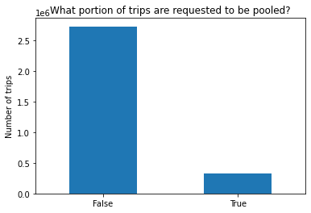

```python
print(trip.shared_trip_authorized.value_counts())
percent_of_shared = trip.shared_trip_authorized.value_counts()[1]/len(trip)
print (f'{round(percent_of_shared,2)}% of total trips are requested to be pooled')
trip.shared_trip_authorized.value_counts().plot(kind='bar')
plt.title('What portion of trips are requested to be pooled?')
plt.xticks(rotation=0)
plt.ylabel('Number of trips')
plt.savefig('images/target_distribution.png', dpi=300)
plt.show()
```

Since the target varible is imbalanced, we should consider precison and recall rather than accuracy.

```python
trip.groupby('shared_trip_authorized').mean()
```

| shared_trip_authorized | trip_seconds | trip_miles | pickup_community_area | dropoff_community_area | fare | tip | additional_charges | trip_total | trips_pooled | pickup_centroid_latitude | pickup_centroid_longitude | dropoff_centroid_latitude | dropoff_centroid_longitude |
| --- | --- | --- | --- | --- | --- | --- | --- | --- | --- | --- | --- | --- | --- |
| False | 944.781605 | 4.542668 | 21.793658 | 22.581960 | 10.362360 | 0.669748 | 3.128046 | 14.160153 | 1.004789 | 41.900359 | -87.657419 | 41.901192 | -87.659827 |
| True | 1178.342448 | 6.319077 | 24.813819 | 24.562201 | 8.572013 | 0.250236 | 1.189183 | 10.011432 | 2.111447 | 41.891531 | -87.660659 | 41.892490 | -87.659300 |

We can see that trips that are authorized to be shared are **longer** and **less expensive**.

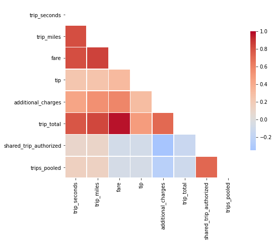

```python
import seaborn as sns

to_drop=['trip_start_timestamp', 'trip_end_timestamp',  'pickup_census_tract',
         'pickup_community_area','dropoff_community_area',
         'dropoff_census_tract','pickup_centroid_latitude', 'pickup_centroid_longitude',
         'dropoff_centroid_latitude', 'dropoff_centroid_longitude']


fig, ax = plt.subplots(figsize=(8,8))
matrix = np.triu(trip.drop(to_drop, axis=1).corr())
sns.heatmap(trip.drop(to_drop, axis=1).corr(), annot=False, mask=matrix, fmt='.1g', square=True, linewidths=.5, cbar_kws={"shrink": .5}, \
            center=0, cmap='coolwarm',ax=ax)
plt.tight_layout()
plt.savefig('images/heatmap.png', dpi=300)
```

I found that “Additional Charges” has conspicuous correlation with “shared_trip_authorized”. So, this variable might be one of the important features in model prediction. This is expected, since economical trip is most likely to be one of the incentives for a person to request a shared trip.

## Baseline

```python
from sklearn.ensemble import RandomForestClassifier
from sklearn.model_selection import train_test_split
from sklearn.metrics import log_loss
from sklearn.metrics import classification_report
from sklearn.metrics import precision_score
from sklearn.metrics import recall_score
from sklearn.metrics import classification_report


s = trip.sample(n=5000, random_state=4)
X=s[['trip_seconds', 'trip_miles', 'fare', 'tip',  'additional_charges','trip_total']]
y=s['shared_trip_authorized']

X_train, X_test, y_train, y_test = train_test_split(X, y, random_state=0, stratify = y )


rf = RandomForestClassifier(max_depth=7).fit(X_train, y_train)
rf_pred=rf.predict(X_test)
rf_probs = rf.predict_proba(X_test)

print('log_loss:', log_loss(y_test, rf_probs))
print('--'*12)
print('train score accuracy', rf.score(X_train, y_train))
print('test score accuracy', rf.score(X_test, y_test))
print('--'*12)

print('train score precision', precision_score(y_test, rf_pred))
print('test score precision', precision_score(y_test, rf_pred))
print('--'*12)
print('train score recall', recall_score(y_test, rf_pred))
print('test score recall', recall_score(y_test, rf_pred))
print('--'*12)
print('\n')
print(classification_report(y_test, rf_pred, labels=[0, 1]))
```

```
log_loss: 0.09434126345148544
------------------------
train score accuracy 0.9722666666666666
test score accuracy 0.9752
------------------------
train score precision 0.9626168224299065
test score precision 0.9626168224299065
------------------------
train score recall 0.7923076923076923
test score recall 0.7923076923076923
------------------------


              precision    recall  f1-score   support

           0       0.98      1.00      0.99      1120
           1       0.96      0.79      0.87       130

    accuracy                           0.98      1250
   macro avg       0.97      0.89      0.93      1250
weighted avg       0.97      0.98      0.97      1250
```

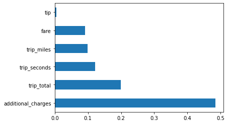

```python
feat_importances = pd.Series(rf.feature_importances_, index=X.columns)
feat_importances.nlargest(10).plot(kind='barh')
```

```python
#trip.to_csv('data/data_1to14_eda.csv', index=False)
```

## Feature Engineering

```python
import pandas as pd
import numpy as np

import matplotlib.pyplot as plt

import warnings
warnings.filterwarnings(action='ignore')

trip= pd.read_csv('data/data_1to14_eda.csv')
```

Creating a new variable to whether the trip was successfully pooled or not:

- pooled : 1
- not pooled (solo): 0

Traveler could authorize a shared trip but no matching could be made through the trip (variable Shared.Trip.Authorized could be true or false).

```python
trip['trips_pooled'] = np.where(trip['trips_pooled']>1, 1, 0)
```

Change trip_start_timestamp and trip_end_timestamp to datetime object:

```python
trip['trip_start_timestamp'] = pd.to_datetime(trip['trip_start_timestamp'])
trip['trip_end_timestamp'] = pd.to_datetime(trip['trip_end_timestamp'])
```

Creating a column showing day of week of each trip.

The week starts on Monday:

- Monday: 0
- .
- .
- .
- Sunday: 6

```python
trip['dayofweek'] = trip['trip_start_timestamp'].dt.dayofweek
```

Creating a column showing if the trip is done on weekdays or weekends?

```python
trip['is_weekend']=np.where(trip['dayofweek'].isin([5,6]), 1, 0)
```

Creating a column showing the session of the trip:

```python
b = [0,5,9,16,20,24]
l = ['midnight', 'm_peak','non_peak','e_peak', 'night']
trip['day_session'] = pd.cut(trip['trip_start_timestamp'].dt.hour, bins=b, labels=l, include_lowest=True)
```

```python
trip['hour'] = trip['trip_start_timestamp'].dt.hour
```

Creating a column showing the month of the trip:

```python
trip['month'] = trip['trip_start_timestamp'].dt.month
```

```python
trip.info()
```

```
<class 'pandas.core.frame.DataFrame'>
RangeIndex: 3051324 entries, 0 to 3051323
Data columns (total 23 columns):
 #   Column                      Dtype
---  ------                      -----
 0   trip_start_timestamp        datetime64[ns]
 1   trip_end_timestamp          datetime64[ns]
 2   trip_seconds                float64
 3   trip_miles                  float64
 4   pickup_census_tract         int64
 5   dropoff_census_tract        int64
 6   pickup_community_area       float64
 7   dropoff_community_area      float64
 8   fare                        float64
 9   tip                         float64
 10  additional_charges          float64
 11  trip_total                  float64
 12  shared_trip_authorized      int64
 13  trips_pooled                int64
 14  pickup_centroid_latitude    float64
 15  pickup_centroid_longitude   float64
 16  dropoff_centroid_latitude   float64
 17  dropoff_centroid_longitude  float64
 18  dayofweek                   int64
 19  is_weekend                  int64
 20  day_session                 category
 21  hour                        int64
 22  month                       int64
dtypes: category(1), datetime64[ns](2), float64(12), int64(8)
memory usage: 515.1 MB
```

```python
ACS_data = pd.read_csv('data/chicago_sociodem_tract.csv',
                   sep=',')
ACS_data.info()
```

```
<class 'pandas.core.frame.DataFrame'>
RangeIndex: 801 entries, 0 to 800
Data columns (total 12 columns):
 #   Column               Non-Null Count  Dtype
---  ------               --------------  -----
 0   GEOID                801 non-null    int64
 1   portion_low_income   801 non-null    float64
 2   portion_high_income  801 non-null    float64
 3   portion_bachelor_up  801 non-null    float64
 4   portion_female       801 non-null    float64
 5   portion_no_car       801 non-null    float64
 6   portion_white        801 non-null    float64
 7   portion_black        801 non-null    float64
 8   portion_twoplus      801 non-null    float64
 9   portion_hispanic     801 non-null    float64
 10  portion_renter_occ   801 non-null    float64
 11  portion_young18_44   801 non-null    float64
dtypes: float64(11), int64(1)
memory usage: 75.2 KB
```

```python
data = pd.merge(trip, ACS_data.add_suffix('_pickup'), how='left' , left_on='pickup_census_tract', right_on='GEOID_pickup',  suffixes=(None, '_pickup')).drop(['GEOID_pickup'],axis=1 )
data = pd.merge(data, ACS_data.add_suffix('_dropoff'), how='left' , left_on='dropoff_census_tract', right_on='GEOID_dropoff',  suffixes=(None, '_dropoff')).drop(['GEOID_dropoff'],axis=1 )
```

## Crime Density

```python
crime = pd.read_csv('data/Control_Variables/Crime_Rate/Chicago_crime_GEOID_mapped.csv')
```

```python
data = pd.merge(data, crime.add_suffix('_pickup'), left_on='pickup_census_tract', \
         right_on='GEOID_pickup',  suffixes=(None, '_pickup')).drop(['GEOID_pickup', 'n_pickup'],axis=1 )

data = pd.merge(data, crime.add_suffix('_dropoff'), left_on='dropoff_census_tract', \
         right_on='GEOID_dropoff',  suffixes=(None, '_dropoff')).drop(['GEOID_dropoff', 'n_dropoff'],axis=1 )
```

```python
data.info()
```

```
<class 'pandas.core.frame.DataFrame'>
Int64Index: 3051324 entries, 0 to 3051323
Data columns (total 47 columns):
 #   Column                       Dtype
---  ------                       -----
 0   trip_start_timestamp         datetime64[ns]
 1   trip_end_timestamp           datetime64[ns]
 2   trip_seconds                 float64
 3   trip_miles                   float64
 4   pickup_census_tract          int64
 5   dropoff_census_tract         int64
 6   pickup_community_area        float64
 7   dropoff_community_area       float64
 8   fare                         float64
 9   tip                          float64
```

[output cut: 39 more lines]

## Job Density

```python
job = pd.read_csv('data/Control_Variables/Employment_Density/Chicago_Job_Density.csv')
```

```python
data = pd.merge(data, job.add_suffix('_pickup'), left_on='pickup_census_tract', \
         right_on='GEOID_pickup',  suffixes=(None, '_pickup')).drop(['GEOID_pickup', 'count_jobs_pickup', 'area_pickup'],axis=1 )

data = pd.merge(data, job.add_suffix('_dropoff'), left_on='dropoff_census_tract', \
         right_on='GEOID_dropoff',  suffixes=(None, '_dropoff')).drop(['GEOID_dropoff', 'count_jobs_dropoff', 'area_dropoff'],axis=1 )
```

## Housing

```python
hp = pd.read_csv('data/Control_Variables/Housing_and_Population/Chicago_house_pop_GEOID_mapped.csv')
```

```python
data = pd.merge(data, hp.add_suffix('_pickup'), left_on='pickup_census_tract', \
         right_on='GEOID_pickup',  suffixes=(None, '_pickup')).drop(['GEOID_pickup', 'house_pickup', 'pop_pickup'],axis=1 )

data = pd.merge(data, hp.add_suffix('_dropoff'), left_on='dropoff_census_tract', \
         right_on='GEOID_dropoff',  suffixes=(None, '_dropoff')).drop(['GEOID_dropoff', 'house_dropoff', 'pop_dropoff'],axis=1 )
```

## POI

```python
poi = pd.read_csv('data/Control_Variables/POI/POI_GEOID_mapped.csv')
```

```python
data = pd.merge(data, poi.add_suffix('_pickup'), left_on='pickup_census_tract', \
         right_on='GEOID_pickup',  suffixes=(None, '_pickup')).drop(['GEOID_pickup'],axis=1 )

data = pd.merge(data, poi.add_suffix('_dropoff'), left_on='dropoff_census_tract', \
         right_on='GEOID_dropoff',  suffixes=(None, '_dropoff')).drop(['GEOID_dropoff'],axis=1 )
```

## Transit Supply

```python
transit = pd.read_csv('data/Control_Variables/Transit_Supply/Chicago_transit_supply_GEOID_mapped.csv')
```

```python
data = pd.merge(data, transit.add_suffix('_pickup'), left_on='pickup_census_tract', \
         right_on='GEOID_pickup',  suffixes=(None, '_pickup')).drop(['GEOID_pickup', 'rail_stops_count_pickup', 'bus_stops_count_pickup'],axis=1 )

data = pd.merge(data, transit.add_suffix('_dropoff'), left_on='dropoff_census_tract', \
         right_on='GEOID_dropoff',  suffixes=(None, '_dropoff')).drop(['GEOID_dropoff', 'rail_stops_count_dropoff', 'bus_stops_count_dropoff'],axis=1 )
```

## Weather

```python
#pd.read_csv('data/Control_Variables/Weather_Data/weatherdata.csv')
```

```python
data.info()
```

[output not shown]

### airport

```python
airport_geoid = ['17031980100', '17031980000']

data['is_airport']=np.where(data['pickup_census_tract'].isin(airport_geoid) | data['dropoff_census_tract'].isin(airport_geoid) , 1, 0)
```

```python
data.info()
```

```
<class 'pandas.core.frame.DataFrame'>
Int64Index: 3051324 entries, 0 to 3051323
Data columns (total 60 columns):
 #   Column                       Dtype
---  ------                       -----
 0   trip_start_timestamp         datetime64[ns]
 1   trip_end_timestamp           datetime64[ns]
 2   trip_seconds                 float64
 3   trip_miles                   float64
 4   pickup_census_tract          int64
 5   dropoff_census_tract         int64
 6   pickup_community_area        float64
 7   dropoff_community_area       float64
 8   fare                         float64
 9   tip                          float64
```

[output cut: 52 more lines]

```python
to_drop = ['trip_start_timestamp', 'trip_end_timestamp']


# to_drop = ['trip_start_timestamp', 'trip_end_timestamp',
#            'pickup_community_area', 'dropoff_community_area',
#            'pickup_centroid_latitude', 'pickup_centroid_longitude',
#            'dropoff_centroid_latitude', 'dropoff_centroid_longitude',
#            'portion_twoplus_pickup','portion_twoplus_dropoff',
#            'portion_hispanic_pickup','portion_hispanic_dropoff',
#            'portion_renter_occ_pickup','portion_renter_occ_dropoff']

data.drop(to_drop, axis=1, inplace=True)
```

```python
data.shared_trip_authorized  = np.where(data.shared_trip_authorized == False, 0, 1)
```

```python
data.info()
```

```
<class 'pandas.core.frame.DataFrame'>
Int64Index: 3051324 entries, 0 to 3051323
Data columns (total 58 columns):
 #   Column                       Dtype
---  ------                       -----
 0   trip_seconds                 float64
 1   trip_miles                   float64
 2   pickup_census_tract          int64
 3   dropoff_census_tract         int64
 4   pickup_community_area        float64
 5   dropoff_community_area       float64
 6   fare                         float64
 7   tip                          float64
 8   additional_charges           float64
 9   trip_total                   float64
```

[output cut: 50 more lines]

```python
group = ['pickup_census_tract', 'dropoff_census_tract', 'hour', 'is_weekend', 'is_airport']

s = data.groupby(group)
```

```python
s = s.agg({'trip_seconds':'mean',
           'trip_miles': 'mean',
           'trip_total':'mean',
           'portion_twoplus_pickup': 'median','portion_twoplus_dropoff':'median',
           'portion_hispanic_pickup':'median','portion_hispanic_dropoff':'median',
           'portion_renter_occ_pickup':'median','portion_renter_occ_dropoff':'median',
           'crime_density_pickup':'median','house_density_pickup':'median',
           'job_density_pickup': 'median', 'job_density_dropoff': 'median',
           'house_density_pickup':'median', 'house_density_dropoff': 'median',
           'pop_density_pickup': 'median', 'pop_density_dropoff': 'median',
           'POI_density_pickup':'median', 'POI_density_dropoff': 'median',
           'bus_stops_density_pickup': 'median', 'bus_stops_density_dropoff': 'median',
          'rail_stops_density_pickup': 'median', 'rail_stops_density_dropoff': 'median',
          'trips_pooled': 'count',
          'shared_trip_authorized': lambda x: x.sum()/len(x)
         }).reset_index()
```

```python
s['midnight'] = s['hour'].apply(lambda x: 1 if (x>=0 and x<5) else 0)
s['m_peak'] = s['hour'].apply(lambda x: 1 if (x>=5 and x<9) else 0)
s['non_peak'] = s['hour'].apply(lambda x: 1 if (x>=9 and x<16) else 0)
s['e_peak'] = s['hour'].apply(lambda x: 1 if (x>=16 and x<20) else 0)
s['night'] = s['hour'].apply(lambda x: 1 if (x>=20 and x<24) else 0)
```

```python
s = s.rename(columns={'trips_pooled': 'count'})
```

```python
s.shape
```

```
(993986, 31)
```

```python
s=s[s['count'] > 100]
```

```python
s.shape
```

[output not shown]

```python
s = s.fillna(0)
s.isna().sum()
```

[output not shown]

```python
s.info()
```

[output not shown]

[output cut: 23 more lines]

```python
from sklearn.preprocessing import MinMaxScaler
scaler = MinMaxScaler()

s_scaled = pd.DataFrame(scaler.fit_transform(s), columns=s.columns)
s_scaled.head(2)
```

|  | pickup_census_tract | dropoff_census_tract | hour | is_weekend | is_airport | trip_seconds | trip_miles | additional_charges | fare | tip | ... | pop_density_pickup | pop_density_dropoff | POI_density_pickup | POI_density_dropoff | bus_stops_density_pickup | bus_stops_density_dropoff | rail_stops_density_pickup | rail_stops_density_dropoff | count | shared_trip_authorized |
| --- | --- | --- | --- | --- | --- | --- | --- | --- | --- | --- | --- | --- | --- | --- | --- | --- | --- | --- | --- | --- | --- |
| 0 | 0.0 | 0.0 | 0.043478 | 1.0 | 0.0 | 0.002430 | 0.000000 | 0.130036 | 0.017857 | 0.0 | ... | 0.116825 | 0.116825 | 0.081782 | 0.081782 | 0.048466 | 0.048466 | 0.0 | 0.0 | 0.0 | 0.0 |
| 1 | 0.0 | 0.0 | 0.347826 | 0.0 | 0.0 | 0.032374 | 0.013544 | 0.130036 | 0.035714 | 0.0 | ... | 0.116825 | 0.116825 | 0.081782 | 0.081782 | 0.048466 | 0.048466 | 0.0 | 0.0 | 0.0 | 0.0 |

2 rows × 31 columns

```python
cols = [0,1,30]
X=s.drop(s.columns[cols], axis=1)
y=s['shared_trip_authorized']
```

```python
import statsmodels.api as sm
X = sm.add_constant(X)
est = sm.OLS(y, X).fit()
est.summary()
```

OLS Regression Results

| Dep. Variable: | shared_trip_authorized | R-squared: | 0.477 |
| --- | --- | --- | --- |
| Model: | OLS | Adj. R-squared: | 0.477 |
| Method: | Least Squares | F-statistic: | 3.235e+04 |
| Date: | Wed, 02 Dec 2020 | Prob (F-statistic): | 0.00 |
| Time: | 12:43:10 | Log-Likelihood: | 27697. |
| No. Observations: | 992056 | AIC: | -5.534e+04 |
| Df Residuals: | 992027 | BIC: | -5.499e+04 |
| Df Model: | 28 |  |  |
| Covariance Type: | nonrobust |  |  |

|  | coef | std err | t | P>\|t\| | [0.025 | 0.975] |
| --- | --- | --- | --- | --- | --- | --- |
| const | 0.7189 | 0.002 | 370.860 | 0.000 | 0.715 | 0.723 |
| hour | -0.0008 | 3.72e-05 | -21.042 | 0.000 | -0.001 | -0.001 |
| is_weekend | -0.0199 | 0.000 | -40.566 | 0.000 | -0.021 | -0.019 |
| is_airport | 0.8791 | 0.002 | 388.766 | 0.000 | 0.875 | 0.884 |
| trip_seconds | 0.0002 | 7.27e-07 | 247.545 | 0.000 | 0.000 | 0.000 |
| trip_miles | 0.0314 | 0.000 | 267.025 | 0.000 | 0.031 | 0.032 |
| additional_charges | -0.1912 | 0.000 | -620.387 | 0.000 | -0.192 | -0.191 |
| fare | -0.0394 | 8.99e-05 | -437.526 | 0.000 | -0.040 | -0.039 |
| tip | -0.0058 | 0.000 | -26.742 | 0.000 | -0.006 | -0.005 |
| portion_twoplus_pickup | -0.2484 | 0.012 | -20.122 | 0.000 | -0.273 | -0.224 |
| portion_twoplus_dropoff | -0.2822 | 0.012 | -23.060 | 0.000 | -0.306 | -0.258 |
| portion_hispanic_pickup | 0.0176 | 0.001 | 13.457 | 0.000 | 0.015 | 0.020 |
| portion_hispanic_dropoff | 0.0429 | 0.001 | 32.297 | 0.000 | 0.040 | 0.046 |
| portion_renter_occ_pickup | 0.0444 | 0.002 | 27.074 | 0.000 | 0.041 | 0.048 |
| portion_renter_occ_dropoff | 0.0642 | 0.002 | 39.154 | 0.000 | 0.061 | 0.067 |
| crime_density_pickup | 1.309e-06 | 6.14e-08 | 21.318 | 0.000 | 1.19e-06 | 1.43e-06 |
| house_density_pickup | 7.76e-07 | 7.34e-08 | 10.573 | 0.000 | 6.32e-07 | 9.2e-07 |
| job_density_pickup | -7.195e-08 | 3.83e-09 | -18.800 | 0.000 | -7.94e-08 | -6.44e-08 |
| job_density_dropoff | -6.437e-08 | 3.02e-09 | -21.297 | 0.000 | -7.03e-08 | -5.84e-08 |
| house_density_dropoff | 9.711e-07 | 6.77e-08 | 14.348 | 0.000 | 8.38e-07 | 1.1e-06 |
| pop_density_pickup | -1.596e-06 | 5.23e-08 | -30.507 | 0.000 | -1.7e-06 | -1.49e-06 |
| pop_density_dropoff | -1.363e-06 | 5.02e-08 | -27.154 | 0.000 | -1.46e-06 | -1.26e-06 |
| POI_density_pickup | -4.428e-05 | 1.36e-06 | -32.491 | 0.000 | -4.7e-05 | -4.16e-05 |
| POI_density_dropoff | -4.817e-05 | 1.29e-06 | -37.340 | 0.000 | -5.07e-05 | -4.56e-05 |
| bus_stops_density_pickup | -8.888e-05 | 8.65e-06 | -10.277 | 0.000 | -0.000 | -7.19e-05 |
| bus_stops_density_dropoff | -0.0001 | 8.43e-06 | -14.818 | 0.000 | -0.000 | -0.000 |
| rail_stops_density_pickup | -0.0003 | 2.66e-05 | -13.137 | 0.000 | -0.000 | -0.000 |
| rail_stops_density_dropoff | -0.0003 | 2.66e-05 | -11.997 | 0.000 | -0.000 | -0.000 |
| count | 0.0008 | 4.43e-05 | 17.291 | 0.000 | 0.001 | 0.001 |

| Omnibus: | 428467.968 | Durbin-Watson: | 1.804 |
| --- | --- | --- | --- |
| Prob(Omnibus): | 0.000 | Jarque-Bera (JB): | 2108875.746 |
| Skew: | 2.091 | Prob(JB): | 0.00 |
| Kurtosis: | 8.790 | Cond. No. | 5.79e+06 |

Warnings:  
[1] Standard Errors assume that the covariance matrix of the errors is correctly specified.  
[2] The condition number is large, 5.79e+06. This might indicate that there are  
strong multicollinearity or other numerical problems.

[figure not shown]

```python
import seaborn as sns

to_drop=[0,1]


fig, ax = plt.subplots(figsize=(20,20))
matrix = np.triu(s.drop(s.columns[to_drop], axis=1).corr())
sns.heatmap(s.drop(s.columns[to_drop], axis=1).corr(), annot=True, fmt='.1g', square=True, linewidths=.5, cbar_kws={"shrink": .5},ax=ax)
plt.tight_layout()
plt.savefig('images/heatmap.png', dpi=300)
```

## What are underlying factors for WTP?

```python
data.info()
```

[output not shown]

```python
pd.crosstab(data.is_airport, data.shared_trip_authorized, normalize=False).plot(kind="bar")
plt.title('WTP (trip shared authorized ~ additional charges)')
plt.xticks(rotation=0)
plt.ylabel('Frequency')
#plt.savefig('1.png')
plt.show()
```

[output not shown]

```python
from scipy.stats import chi2_contingency
chi2, p, dof, ex = chi2_contingency( pd.crosstab(data.is_airport, data.shared_trip_authorized, margins=True))
print("chi2 = ", chi2)
print("p-val = ", p)
print("degree of freedom = ",dof)
```

[output not shown]

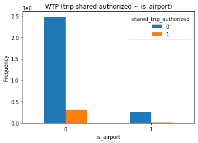

```python
pd.crosstab(data.is_airport, data.shared_trip_authorized, normalize=False).plot(kind="bar")
plt.title('WTP (trip shared authorized ~ is_airport)')
plt.xticks(rotation=0)
plt.ylabel('Frequency')
#plt.savefig('1.png')
plt.show()
```

```python
from scipy.stats import chi2_contingency
chi2, p, dof, ex = chi2_contingency( pd.crosstab(data.is_airport, data.shared_trip_authorized, margins=True))
print("chi2 = ", chi2)
print("p-val = ", p)
print("degree of freedom = ",dof)
```

```
chi2 =  6351.264506938556
p-val =  0.0
degree of freedom =  4
```

```python
import statsmodels.api as sm
import statsmodels.formula.api as smf

cols = ['trip_seconds', 'trip_miles', 'fare', 'tip', 'additional_charges',
       'trip_total', 'hour', 'month', 'portion_low_income_pickup',
       'portion_high_income_pickup', 'portion_bachelor_up_pickup',
       'portion_female_pickup', 'portion_no_car_pickup',
       'portion_white_pickup', 'portion_black_pickup',
       'portion_twoplus_pickup', 'portion_hispanic_pickup',
       'portion_renter_occ_pickup', 'portion_young18_44_pickup',
       'portion_low_income_dropoff', 'portion_high_income_dropoff',
       'portion_bachelor_up_dropoff', 'portion_female_dropoff',
       'portion_no_car_dropoff', 'portion_white_dropoff',
       'portion_black_dropoff', 'portion_twoplus_dropoff',
       'portion_hispanic_dropoff', 'portion_renter_occ_dropoff',
       'portion_young18_44_dropoff']

dict_pval={}
for item in cols:
    model1 = smf.ols(f'{item} ~ C(shared_trip_authorized)', data=data).fit()
    dict_pval[item] = model1.f_pvalue
```

```python
dict_pval
```

```
{'trip_seconds': 0.0,
 'trip_miles': 0.0,
 'fare': 0.0,
 'tip': 0.0,
 'additional_charges': 0.0,
 'trip_total': 0.0,
 'hour': 2.277939007292422e-07,
 'month': 1.0,
 'portion_low_income_pickup': 0.0,
 'portion_high_income_pickup': 0.0,
 'portion_bachelor_up_pickup': 0.0,
 'portion_female_pickup': 0.0,
 'portion_no_car_pickup': 3.1344329999657895e-225,
 'portion_white_pickup': 0.0,
 'portion_black_pickup': 0.0,
 'portion_twoplus_pickup': 3.150332215877822e-69,
 'portion_hispanic_pickup': 0.0,
 'portion_renter_occ_pickup': 0.0,
 'portion_young18_44_pickup': 0.0,
 'portion_low_income_dropoff': 0.0,
 'portion_high_income_dropoff': 0.0,
 'portion_bachelor_up_dropoff': 0.0,
 'portion_female_dropoff': 0.0,
 'portion_no_car_dropoff': 8.952571556612613e-49,
 'portion_white_dropoff': 0.0,
 'portion_black_dropoff': 0.0,
 'portion_twoplus_dropoff': 0.10323990411105204,
 'portion_hispanic_dropoff': 0.0,
 'portion_renter_occ_dropoff': 0.0,
 'portion_young18_44_dropoff': 0.0}
```

```python
pd.DataFrame.from_dict(dict_pval,'index').stack().reset_index(level=0)
```

|  | level_0 | 0 |
| --- | --- | --- |
| 0 | trip_seconds | 0.000000e+00 |
| 0 | trip_miles | 0.000000e+00 |
| 0 | fare | 0.000000e+00 |
| 0 | tip | 0.000000e+00 |
| 0 | additional_charges | 0.000000e+00 |
| 0 | trip_total | 0.000000e+00 |
| 0 | hour | 2.277939e-07 |
| 0 | month | 1.000000e+00 |
| 0 | portion_low_income_pickup | 0.000000e+00 |
| 0 | portion_high_income_pickup | 0.000000e+00 |
| 0 | portion_bachelor_up_pickup | 0.000000e+00 |
| 0 | portion_female_pickup | 0.000000e+00 |
| 0 | portion_no_car_pickup | 3.134433e-225 |
| 0 | portion_white_pickup | 0.000000e+00 |
| 0 | portion_black_pickup | 0.000000e+00 |
| 0 | portion_twoplus_pickup | 3.150332e-69 |
| 0 | portion_hispanic_pickup | 0.000000e+00 |
| 0 | portion_renter_occ_pickup | 0.000000e+00 |
| 0 | portion_young18_44_pickup | 0.000000e+00 |
| 0 | portion_low_income_dropoff | 0.000000e+00 |
| 0 | portion_high_income_dropoff | 0.000000e+00 |
| 0 | portion_bachelor_up_dropoff | 0.000000e+00 |
| 0 | portion_female_dropoff | 0.000000e+00 |
| 0 | portion_no_car_dropoff | 8.952572e-49 |
| 0 | portion_white_dropoff | 0.000000e+00 |
| 0 | portion_black_dropoff | 0.000000e+00 |
| 0 | portion_twoplus_dropoff | 1.032399e-01 |
| 0 | portion_hispanic_dropoff | 0.000000e+00 |
| 0 | portion_renter_occ_dropoff | 0.000000e+00 |
| 0 | portion_young18_44_dropoff | 0.000000e+00 |

```python
#data.to_csv('trip_Nov_1to14_clean.csv', index=False)
```